# Summary of PARTS Simulations

Clay Morrow

7/28/2021

# Introduction

This document will summarize the results of simulation studies used to evaluate the robustness of the PARTS method.

# Methods

## Model

All data were generated with the following simulation model:

$$X(t) = \lambda L + \psi_1 R_1 + t(\alpha + \beta L +\psi_2 R_2 ) + (\gamma + \psi_3 R_3)W(t) + \varepsilon(t)$$

- $X(t)$ is the observed spatio-temporal variable at time $t$
- $L$ is a indicator variable for one of two land classes (0, 1) and $\lambda$ is the intercept effect of land class 1 relative to land class 0. Land class was generated in a regular (checkerboard) grid with granularity of 2, 4, or 8 where one square block of land is 1/2, 1/4, or 1/8 the width of the map respectively.
- $\alpha$ is the baseline effect of time and $\beta$ is the interaction between time and land class
- $W(t) \sim N(0, \Sigma_w)$ is a spatio-temporal predictor, representing a climate variable and $\gamma$ is the baseline effect of climate. $\Sigma_w$ is the covariance structure of $W$.
- $R_1$, $R_2$, and $R_3$ are additional random effects on the intercept, time, and climate components of the model respectively. $\psi_i$ are magnitudes ( variance) of these random effects.
- $\varepsilon(t)$ is the spatio-temporally autocorrelated error term which follows an AR(1) process: $\varepsilon(t) = \rho \varepsilon(t-1) + \delta(t)$
  - $\rho$ is the AR parameter, which generates temporal autocorrelation, and
  - $\delta(t) \sim N(0, \Sigma)$ is the spatially autocorrelated error at time $t$, generated with a tapered covariance function: $\Sigma = I\eta + (1-\eta)f(D, \theta)$.
    - $\eta$ is the variance-absorbing nugget,
    - $I$ is an identity matrix
    - $f$ is a tapered covariance function. See below for the formulation.
    - $D$ is the geographic distance between points $i$ and $j$
    - $\theta$ is the effective range of the spatial autocorrelation. Below this distance, $f$ evaluates to 0.
    - Generations of $\Sigma_w$ follows from generation of $\Sigma$, substituting $\theta$ for the climate-specific $\theta_w$.

$$f(D) = \begin{cases} 0 & D < \theta \\ \big(\frac{1 - D}{\theta}\big)^2 \frac{1+D}{2\theta} & else \end{cases}$$

- $W(t)$ is also a generated by an AR process: $W(t) = \rho_w W(t-1) + \delta_w(t)$
  - $\rho_w$ is the AR parameter used to generates $W(t)$ and
  - $\delta_w(t)$
- Each $R$ is a spatial variable following a 2D sin wave: $R = \sin(\frac{2\pi}{T_x}x + p_x + \frac{2\pi}{T_y}y + p_y) + \varepsilon$.
  - Here, $x$ and $y$ are map coordinates.
  - The following parameter values were selected to make realistically smooth transitions across the maps: $T_x = T_y = 0.6$ and $p_x = p_y = 45^\circ$.
  - $\varepsilon \sim N(0, 1)$

# Results

4 Simulation studies were conducted to evaluate the robustness of the PARTS method. During these studies, data were simulated and fit according to the PARTS method.

## Simulation study 1

The first study aimed to identify the effect of map size on Type I error rates of purely spatial data.

- Square maps with widths of 104, 144, 200, and 280 pixels were considered.
- Data were simulated for only one time point $t = 1$.
- All model parameters ($\lambda$, $\alpha$, $\beta$, $\gamma$, $\psi$) were set to zero.
- The spatial range, nugget, and AR parameters were fixed for all simulations: $\theta = 0.05$, $\eta = 0.1$, $\rho = 0.2$.
- 200 simulations were conducted for each map size (n = 200, N = 800).
- granularity of $L$ was 2.
- $\lambda$ was the parameter of interest.

Below are figures showing the coefficient estimate (left) and Type I error rate of $\lambda$ for the 2 land classes. Figures show mean $\pm$ 1 standard error. We can see that:

- coefficient estimates were very close to 0 for all map widths, though the estimates converge on 0 with increasing map size.
- Type I error rates were as expected ($\approx 5\%$).
- A very slight uptick in Type I error of $\lambda_0$ occurred for the 144 pixel map, but this is likely due to the relatively small sample size of 200. Note that, even for this point, all 95% CI for Type I error rates contain 0.05.

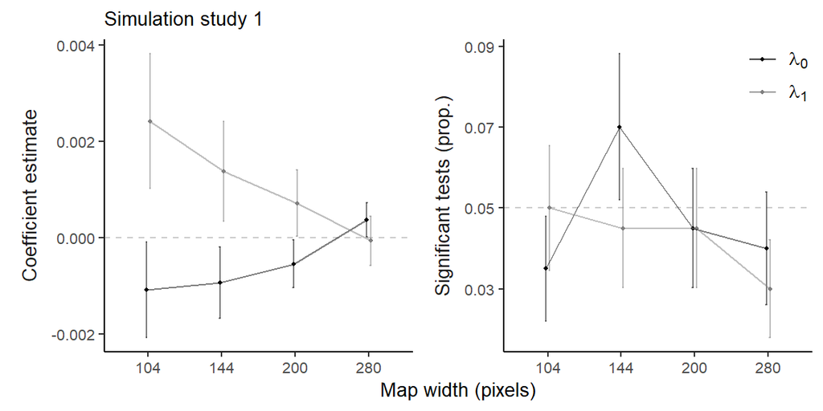

## Simulation study 2

The second study aimed to test the effect of the size and number of land patches (granularity) on the Type I errors among temporal parameters.

- Two granularities were use to generate $L$: 2 and 8.
- Square maps 104 pixels wide were used.
- 30 time points were used ($t = {1, 2, ..., 30}$).
- $\lambda$ was set to a constant 0.1, meaning that land class 1 has $X$ values 0.1 higher than class 0 on average across the map.
- all other model parameters ($\alpha$, $\beta$, $\gamma$, and $\psi$) were set to zero.
- The spatial range, nugget, and AR parameters were fixed for all simulations: $\theta = 0.05$, $\eta = 0.1$, $\rho = 0.2$.
- 200 simulations were generated for each granularity (n = 200, N = 400).
- $\beta$ was the parameter of interest.

Below are the same 2 figures showing the coefficient estimates and Type I error rates of $\beta$ for the 2 land classes.

- coefficient estimates are very close to 0 for all both large and small land patches (2 and 8, respectively) even with a non-zero $\lambda$.
- Type I error rates were as expected ($\approx 5\%$) for $\beta_1$ but were slightly elevated for $\beta_0$ ($0.05 < P(\text{Type I}) <0.75$). However, 95% CIs contain 0.05.

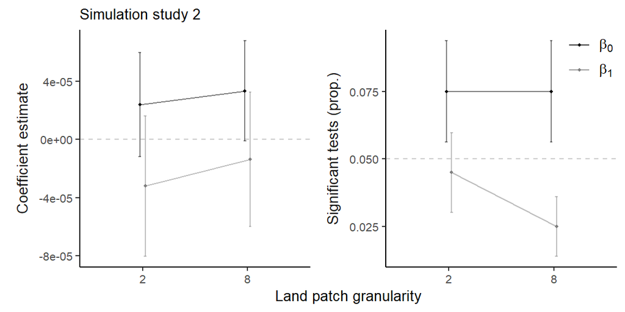

## Simulation study 3

The thirds study aimed to test the Type I error associated with climate variable, with varying the temporal effects.

- Data were simulated with two values of $\psi_2$: 0 and 0.1
- Square maps 104 pixels wide were used.
- 30 time points were used ($t = {1, 2, ..., 30}$).
- $\lambda$ was set to a constant 0.1.
- all other model parameters ($\alpha$, $\beta$, $\gamma$, and $\psi$) were set to zero.
- The spatial range, nugget, and AR parameters were fixed for all simulations: $\theta = 0.05$, $\eta = 0.1$, $\rho = 0.2$.
- granularity of $L$ was 2.
- 200 simulations were conducted for each value of $\psi_2$ (n = 200, N = 400).
- $\gamma$ was the parameter of interest

Below are the figures of results. We can see that:

- While coefficient estimates were close to zero in both cases, including a random temporal effect improved the accuracy of estimates (i.e., the estimates converged on zero with increasing $\psi_2$).
- Type I error rates were as expected ($\approx 5\%$) but increased slightly in the presence of the random effect.

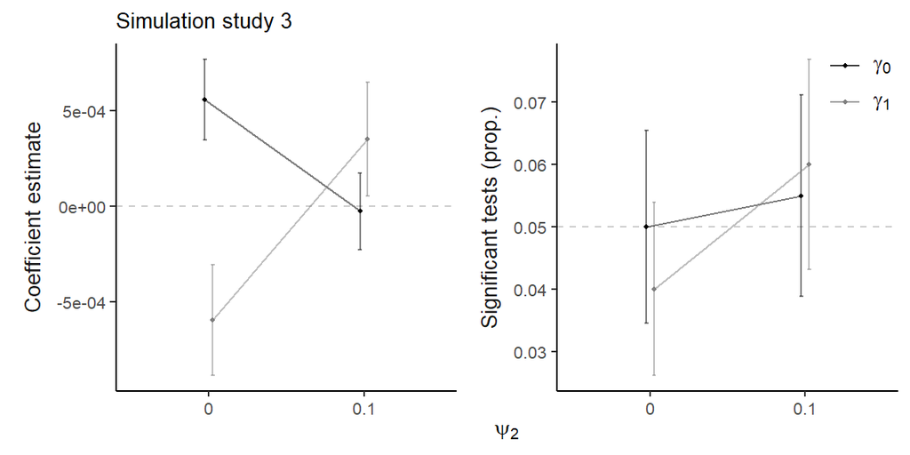

## Simulation study 4

The fourth study aimed to test the effect of various parameters on Type I error rates of $\beta$. This study was broken down into 4 sub-studies, a, b, c, and d.

**Note** Perhaps I should redo (or add to) study 4 with a non-zero value of $\gamma$ as the baseline?

### 4a

Here we tested the effects of including effects of the climate term. We allow the effects of the climate term to vary spatially.

- Data were simulated with 2 levels of $\psi_3$: 0 and 0.1
- Square maps 104 pixels wide were used.
- 30 time points were used ($t = {1, 2, ..., 30}$).
- $\lambda$ was set to a constant 0.1.
- all other model parameters ($\alpha$, $\beta$, $\gamma$, and $\psi$) were set to zero.
- The spatial range, nugget, and AR parameters were fixed for all simulations: $\theta = 0.05$, $\eta = 0.1$, $\rho = 0.2$.
- granularity of $L$ was 2.
- 200 simulations were conducted for each value of $\psi_3$ (n = 200, N = 400).
- $\beta$ was the parameter of interest

From the results, below, we can see that:

- $\beta$ was estimated close to zero for both levels of $\psi_3$
- Type I error was as expected for when $\psi_3 = 0$ but was slightly elevated in $\beta_1$ at $\psi_3 = 0.1$.

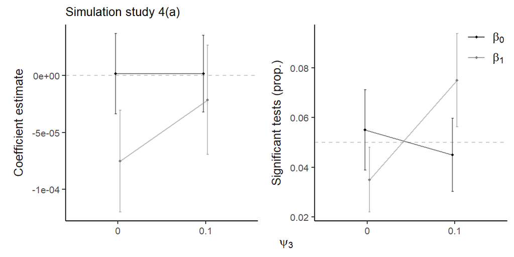

### 4b

Next, we tested the random effect of time:

- Data were simulated with 2 levels of $\psi_2$: 0 and 0.1
- Square maps 104 pixels wide were used.
- 30 time points were used ($t = {1, 2, ..., 30}$).
- $\lambda$ was set to a constant 0.1.
- all other model parameters ($\alpha$, $\beta$, $\gamma$, and $\psi$) were set to zero.
- The spatial range, nugget, and AR parameters were fixed for all simulations: $\theta = 0.05$, $\eta = 0.1$, $\rho = 0.2$.
- granularity of $L$ was 2.
- 200 simulations were conducted for each value of $\psi_2$ (n = 200, N = 400).
- $\beta$ was the parameter of interest

We can see from the below figures that:

- Estimates were close to zero
- Inclusion of a random temporal effect actually reduced the Type I error rate of $\beta$.

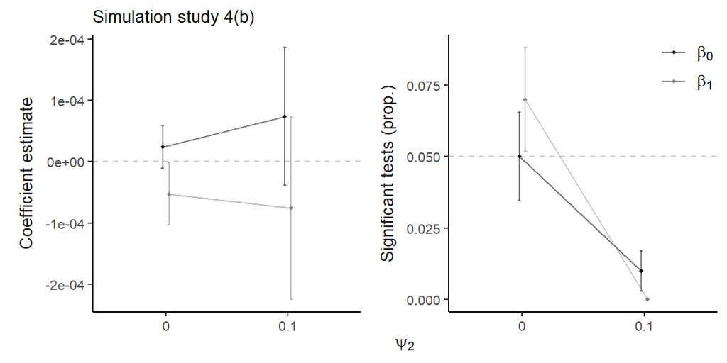

### 4c

Then, we tested the effects of a random intercept effect.

- Data were simulated with 2 levels of $\psi_1$: 0 and 0.1
- Square maps 104 pixels wide were used.
- 30 time points were used ($t = {1, 2, ..., 30}$).
- $\lambda$ was set to a constant 0.1.
- all other model parameters ($\alpha$, $\beta$, $\gamma$, and $\psi$) were set to zero.
- The spatial range, nugget, and AR parameters were fixed for all simulations: $\theta = 0.05$, $\eta = 0.1$, $\rho = 0.2$.
- granularity of $L$ was 2.
- 200 simulations were conducted for each value of $\psi_1$ (n = 200, N = 400).
- $\beta$ was the parameter of interest

We can see from the results that:

- Estimates were close to 0
- Type I error was as expected.

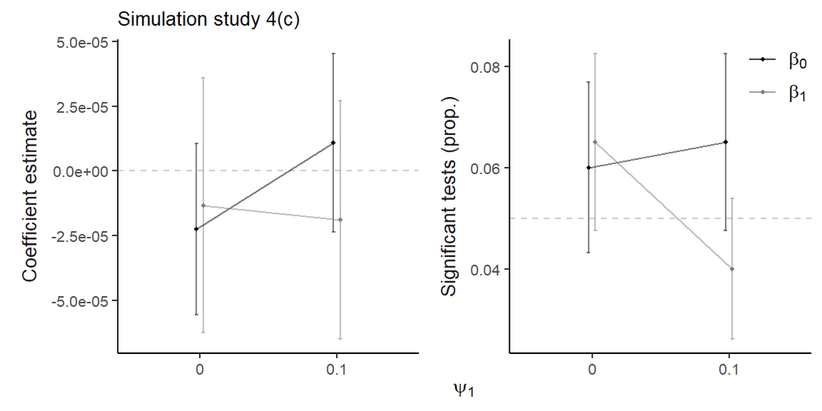

### 4d

Finally, we tested the effect of varying the spatial range parameter:

Results show that:

- While estimates are close to zero, they begin to diverge with higher values of $\theta$.
- Type I error rates are sufficiently low.

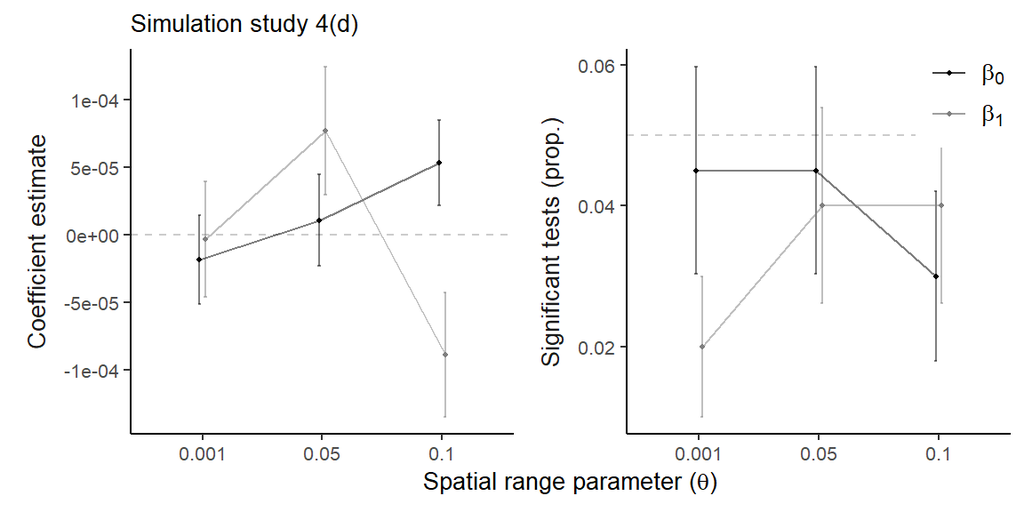

## Compute time

Here is a table of the time needed to conduct each study, in hours:

```
##       elapsed_time_hrs
## sim1          62.18258
## sim2          30.49827
## sim3          31.39818
## sim4         152.36237
## total        276.44140
```

# Conclusions

According to the results of the simulation studies contained in this document, PARTS is sufficiently robust at controlling Type I error and at isolating the main effect, interactions of main effects with time, and effects of spatio-temporal predictors. It is also robust against spatially varying parameters.

# New round of simulations: 09-Sept-2021

After receiving comments from Tony on 22-Aug-2021, We have added the following simulations.

## 1. Purely spatial with tests of land class effects

$$X(t) = \lambda L + \psi_1 R_1 + t(\alpha + \beta L +\psi_2 R_2 ) + (\gamma + \psi_3 R_3)W(t) + \varepsilon(t)$$

For these simulations,

- No temporal autocorrelation: $\alpha = \beta = \psi_2 = 0$
- No spatio-temporal independent variable (i.e., climate): $\gamma = \psi_3 = 0$
- Spatial granularity of 4: **note:** 6 is not possible with my code: only 1, 2, 4, or 8:

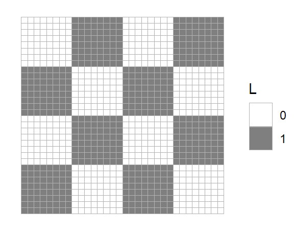

- When $\psi_1 \neq 0$, the function to generate R1 should be fixed:

```r
# 2D sin wave
sin_2d = function(x, y, A = 1, Tx = .6, Ty = .6, px = 45, py = 45){
  A * sin( (2*pi/Tx)*x + px + (2*pi/Ty)*y + py )
}

# function to generate random variables
fixed_r1 <- function(coord.x, coord.y, npix, npeaks){
  tx = ty = 1/(npeaks/2)
  -scale(sin_2d(coord.x, coord.y, Tx = tx, Ty = ty, px = 45, py = 45, A = npix))
}
```

### a. Effect of random spatial autocorrelation ($\theta$)

- constant land class effects: $\lambda_0 = 0$, $\lambda_1 = 0.2$
- $\varepsilon \sim N(0, \Sigma)$:

```r
eps = scale(Sigma %*% matrix(rnorm(ntime), nrow = npix))
```

- no spatially-dependant intercept: $\psi_1 = 0$
- variable range parameter: $\theta = \{0, 0.05, 0.25\}$
- 500 (n) simulations per case: $\text{N} = 500~ \text{n} \times 3~ \text{cases} = 1500$

The desired output is a table/figure of $\lambda_1 - \hat{\lambda_1}$ and potentially empirical 95% intervals (if 500 n is feasible).

### b. Effect of $\theta$ with non-Gaussian errors

Same as (a) but with $\varepsilon$ generated from a $t_3$ distribution rather than a normal distribution:

- $\varepsilon \sim T(3)\Sigma$:

```r
eps = scale(Sigma %*% matrix(rt(ntime, df = 3), nrow = npix))
```

- no spatially-dependant intercept: $\psi_1 = 0$
- **Different case sets:**
  - Case set 1: 500 n each for $\lambda_1 = 0.2$ and $\theta = \{0, 0.05, 0.25\}$
  - Case set 2: 1000 n each for $\lambda_1 = 0$ and $\theta = 0.05$

The desired output is a table/figure of $\lambda_1 - \hat{\lambda_1}$ **and** a visualization of Type I errors when $\lambda_1 = 0$ and $\theta = .05$

### c. Effect of fixed spatial autocorrelation ($R_1$)

- constant land class effects: $\lambda_0 = 0$, $\lambda_1 = 0.2$
- no spatial autocorrelation: $\theta = 0$
- $\varepsilon \sim N(0, \sigma\Sigma)$
- constant $\psi_1 = 2\sigma_{\varepsilon}$: or another value to ensure that R dominates over $\varepsilon$.
- R generated with $T_x = T_y$ such that there 3 cases: are $1^2$, $2^2$, and $3^2$ peaks. When there are $2^2$ peaks, they should align with the center of $L=1$ blocks
- 200 n for each case. Below is the example for $2^2$ peaks **Note:** I could not figure out how to get the peaks to align **exactly** in the center of the blocks, but the default is pretty close:

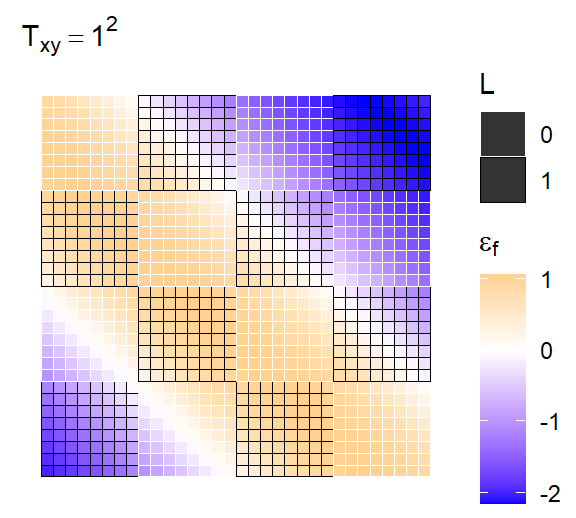

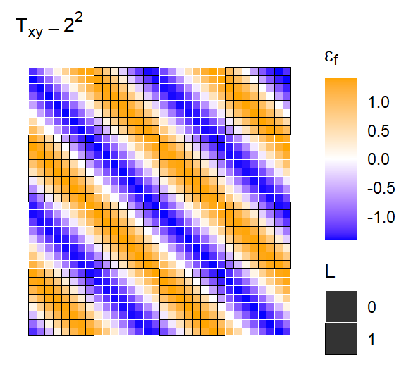

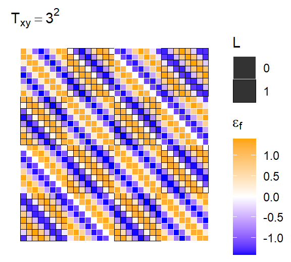

Desired output: $\lambda_1 - \hat{\lambda_1}$ - possibly added to previous Sims

### d. Map Size

No need to do additional sims (see the original set.)

## 2. Spatio-temporal with tests of time trends

$$X(t) = \lambda L + \psi_1 R_1 + t(\alpha + \beta L +\psi_2 R_2 ) + (\gamma + \psi_3 R_3)W(t) + \varepsilon(t)$$

- constant land class effects: $\lambda_0 = 0$, $\lambda_1 = 0.2$
- constant effect of time: $\alpha = \beta_0 = \psi_2 = 0$, and $\beta_1 = \frac{1}{30}$
- no nugget: $\eta = 0$ and tapered covariance
- constant AR parameter: $\rho = 0.4$
- variable effect of spatial range: $\theta = \{0, 0.05, 0.25\}$
- no Spatio-temporal indpendent variable: $\gamma = \phi_3 = 0$
- No fixed spatial autocorrelation: $\psi_1 = 0$
- n = 200 per case

Desired results are $\beta - \hat{\beta}$ with 95% range

## 3. Spatio-temporal with test of spatio-temporal independent variable

$$X(t) = \lambda L + \psi_1 R_1 + t(\alpha + \beta L +\psi_2 R_2 ) + (\gamma + \psi_3 R_3)W(t) + \varepsilon(t)$$

- constant land class effects: $\lambda_0 = 0$, $\lambda_1 = 0.2$
- no fixed spatial effect: $\phi_1 = 0$
- no effect of time: $\alpha = \beta = \phi_2 = 0$
- constant effect of climate variable: $\gamma = 1$ and $\phi_3 = 0$
- constant spatial range (error): $\theta = 0.25$
- variable spatial range of climate: $\theta_W = \{0, 0.25\}$
- variable AR parameter of climate: $\rho_W = \{0, 0.4\}$
- no nugget (error or climate): $\eta = 0$
- n = 200 for each case.

Desired results are $\gamma - \hat{\gamma}$

### Estimated time for second round

total = 112.5 + 187.5 + 3*45 = 435 hrs = 18.13 days…

## Results

```
## Loading objects:
##   sim2.1a
##   sim2.1a_time
```

```
## Loading objects:
##   sim2.1b1
##   sim2.1b2
##   sim2.1b_time
```

```
## Loading objects:
##   sim2.1c1
##   sim2.1c2
##   sim2.1c3
##   sim2.1c_time
```

```
## Loading objects:
##   sim2.2
##   sim2.2_time
```

```
## Loading objects:
##   sim2.3
##   sim2.3_time
```

### compute time

```
##        hours  days
## 2-1   216.63  9.03
## 2-2    57.69  2.40
## 3-3    80.72  3.36
## total 355.04 14.79
```

### 1

####a

| coefficient | r | mean.dif | median.dif | lwr.95 | upr.95 | sig.prop | n |
| --- | --- | --- | --- | --- | --- | --- | --- |
| lambda0 | 0 | 0.000 | 0.000 | -0.026 | 0.031 | 0.046 | 500 |
| lambda0 | 0.05 | 0.000 | 0.000 | -0.029 | 0.027 | 0.048 | 500 |
| lambda0 | 0.25 | 0.001 | 0.002 | -0.031 | 0.027 | 0.048 | 500 |
| lambda1 | 0 | -0.001 | -0.001 | -0.041 | 0.039 | 1.000 | 500 |
| lambda1 | 0.05 | 0.001 | 0.002 | -0.041 | 0.041 | 1.000 | 500 |
| lambda1 | 0.25 | 0.001 | 0.002 | -0.041 | 0.040 | 1.000 | 500 |

[figure not shown]

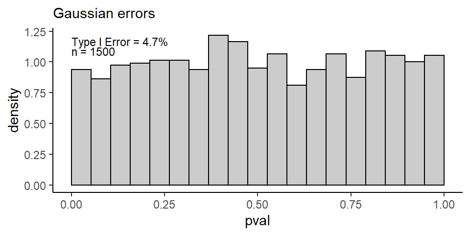

#### b

| lambda | true.coef | coefficient | r | mean.dif | median.dif | lwr.95 | upr.95 | sig.prop | n |
| --- | --- | --- | --- | --- | --- | --- | --- | --- | --- |
| 0.2 | 0.0 | lambda0 | 0 | 0.000 | -0.001 | -0.028 | 0.029 | 0.058 | 500 |
| 0.2 | 0.0 | lambda0 | 0.05 | -0.001 | -0.001 | -0.032 | 0.028 | 0.068 | 500 |
| 0.2 | 0.0 | lambda0 | 0.25 | 0.000 | 0.000 | -0.028 | 0.028 | 0.044 | 500 |
| 0.2 | 0.2 | lambda1 | 0 | 0.001 | 0.001 | -0.039 | 0.041 | 1.000 | 500 |
| 0.2 | 0.2 | lambda1 | 0.05 | 0.001 | 0.001 | -0.036 | 0.042 | 1.000 | 500 |
| 0.2 | 0.2 | lambda1 | 0.25 | 0.000 | -0.001 | -0.042 | 0.044 | 1.000 | 500 |

[figure not shown]

| lambda | coefficient | r | mean.dif | median.dif | lwr.95 | upr.95 | sig.prop | n |
| --- | --- | --- | --- | --- | --- | --- | --- | --- |
| 0 | lambda0 | 0.05 | -0.001 | -0.001 | -0.028 | 0.027 | 0.038 | 1000 |
| 0 | lambda1 | 0.05 | 0.001 | 0.000 | -0.039 | 0.038 | 0.040 | 1000 |

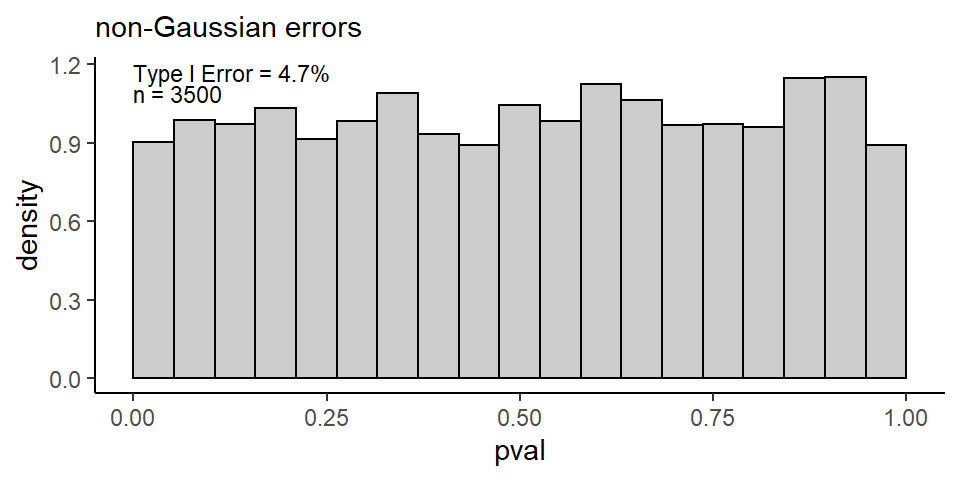

#### c

| coefficient | Tx.Ty | mean.dif | median.dif | lwr.95 | upr.95 | sig.prop | n |
| --- | --- | --- | --- | --- | --- | --- | --- |
| (Intercept) | 1 | -0.050 | -0.051 | -0.063 | -0.037 | 1.00 | 200 |
| (Intercept) | 4 | 0.251 | 0.251 | 0.239 | 0.264 | 1.00 | 200 |
| (Intercept) | 9 | 0.009 | 0.009 | -0.006 | 0.024 | 0.03 | 200 |
| land1 | 1 | 0.101 | 0.101 | 0.081 | 0.120 | 1.00 | 200 |
| land1 | 4 | -0.503 | -0.504 | -0.522 | -0.483 | 1.00 | 200 |
| land1 | 9 | -0.028 | -0.027 | -0.052 | -0.006 | 1.00 | 200 |

[figure not shown]

### 2

| beta | coefficient | r | mean.dif | median.dif | lwr.95 | upr.95 | sig.prop | n | true.coef |
| --- | --- | --- | --- | --- | --- | --- | --- | --- | --- |
| 0.033 | beta0 | 0 | 0 | 0 | -0.001 | 0.001 | 0.055 | 200 | 0.000 |
| 0.033 | beta0 | 0.05 | 0 | 0 | -0.001 | 0.001 | 0.060 | 200 | 0.000 |
| 0.033 | beta0 | 0.25 | 0 | 0 | -0.001 | 0.001 | 0.070 | 200 | 0.000 |
| 0.033 | beta1 | 0 | 0 | 0 | -0.001 | 0.001 | 1.000 | 200 | 0.033 |
| 0.033 | beta1 | 0.05 | 0 | 0 | -0.001 | 0.002 | 1.000 | 200 | 0.033 |
| 0.033 | beta1 | 0.25 | 0 | 0 | -0.002 | 0.002 | 1.000 | 200 | 0.033 |

[figure not shown]

### 3

| temp.r | AR_W | coefficient | mean.dif | median.dif | lwr.95 | upr.95 | sig.prop | n | true.coef |
| --- | --- | --- | --- | --- | --- | --- | --- | --- | --- |
| 0.00 | 0.0 | gamma0 | 0 | 0 | -0.005 | 0.005 | 1.000 | 200 | 1 |
| 0.00 | 0.4 | gamma0 | 0 | 0 | -0.007 | 0.005 | 1.000 | 200 | 1 |
| 0.25 | 0.0 | gamma0 | 0 | 0 | -0.005 | 0.005 | 1.000 | 200 | 1 |
| 0.25 | 0.4 | gamma0 | 0 | 0 | -0.006 | 0.005 | 1.000 | 200 | 1 |
| 0.00 | 0.0 | gamma1 | 1 | 1 | 0.993 | 1.009 | 0.065 | 200 | 1 |
| 0.00 | 0.4 | gamma1 | 1 | 1 | 0.992 | 1.009 | 0.070 | 200 | 1 |
| 0.25 | 0.0 | gamma1 | 1 | 1 | 0.992 | 1.006 | 0.065 | 200 | 1 |
| 0.25 | 0.4 | gamma1 | 1 | 1 | 0.992 | 1.008 | 0.030 | 200 | 1 |

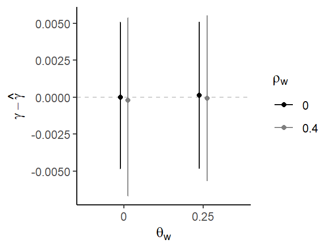

For the GLS model $\gamma \sim land$, we get two results: $\hat\gamma_0$ and $\hat\gamma_1$ even though there is only one $\gamma$ parameter. In our results, $\hat\gamma_0 \approx 1$ means the effect of the climate variable is about 1, while $\hat\gamma_0 \approx 0$ means that the difference between land class 0 and land class 1 is about 0 (i.e., the effect is constant across land class).

[figure not shown]

# All Results

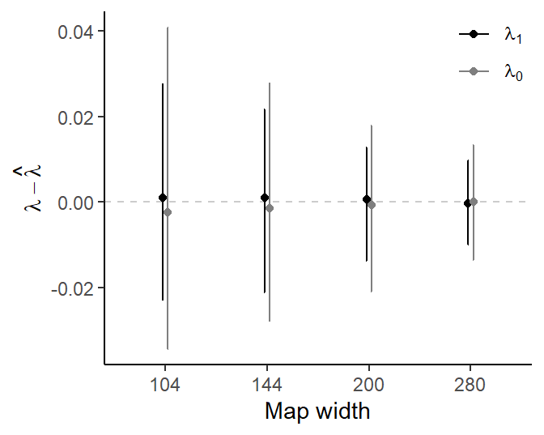

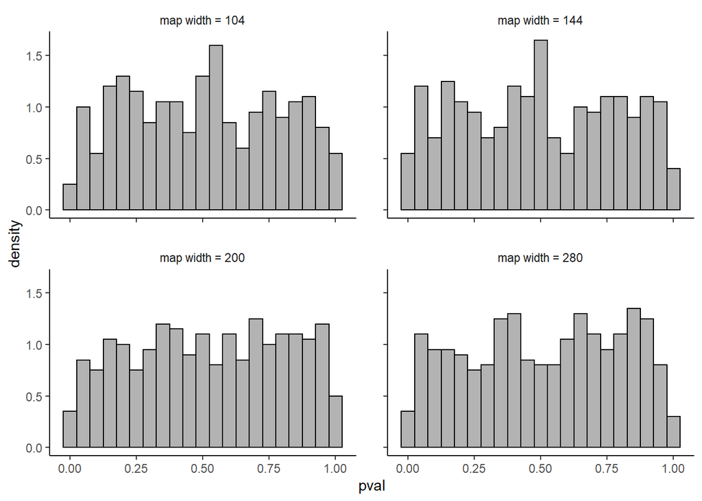

## Look at P-value histograms